# Análisis estadístico para Laura y Matti

Nicolás León

2023-11-27

## 1. Estadística descriptiva

En primer lugar, conviene hacer una revisión de los datos disponibles para entender mejor qué podemos hacer y qué no. Primero leemos la información y la formateamos correctamente:

```r
library(readxl)

df <- read_excel("./data/distance.dataset.xlsx", sheet=1, col_names = TRUE, col_types = c("numeric", "text", "text", "numeric"))

df$structure <- gsub("\\r\\n", "", df$structure)
```

Y usamos esta función para revisar el contenido:

```r
descriptive_stats <- function(type) {
  if(missing(type)) {
    input <- df$distance
  }else{
    input <- df$distance[df$structure==type]
  }

  output <- c(
  paste("mean:", mean(input)),
  paste("median:", median(input)),
  paste("standard deviation", sd(input)),
  paste("IQR:", IQR(input)),
  paste("Min:", min(input)),
  paste("Max:", max(input))
  )

  print(output)
  print(quantile(input))
}
```

Respecto a toda la data, encontramos esto:

```r
descriptive_stats()
```

```
## [1] "mean: 15.0829068577277"              "median: 7"
## [3] "standard deviation 22.0767171264775" "IQR: 22"
## [5] "Min: 0"                              "Max: 194"
##   0%  25%  50%  75% 100%
##    0    0    7   22  194
```

Así como la siguiente información sobre las tres categorías que queremos analizar:

```r
descriptive_stats("overt connective")
```

```
## [1] "mean: 21.8928571428571"              "median: 13.5"
## [3] "standard deviation 25.3281178273562" "IQR: 25.25"
## [5] "Min: 0"                              "Max: 194"
##     0%    25%    50%    75%   100%
##   0.00   5.00  13.50  30.25 194.00
```

```r
descriptive_stats("juxtaposition")
```

```
## [1] "mean: 20.5863636363636"              "median: 14"
## [3] "standard deviation 21.8380672923112" "IQR: 26.25"
## [5] "Min: 0"                              "Max: 128"
##     0%    25%    50%    75%   100%
##   0.00   4.00  14.00  30.25 128.00
```

```r
descriptive_stats("elliptical")
```

```
## [1] "mean: 3.00296735905045"              "median: 0"
## [3] "standard deviation 8.98593428520919" "IQR: 1"
## [5] "Min: 0"                              "Max: 65"
##   0%  25%  50%  75% 100%
##    0    0    0    1   65
```

Como podemos observar hay dos cosas importantes a considerar:

1. Solo tenemos una columna numérica y otra columna categoríca. Esto imposibilita la regresión lineal planteada en un inicio. Asimismo, imposibilita un análisis multivariado, ya que solo tenemos información categórica.
2. Las categorías **over connective** y **juxtaposition** tienen características parecidas, aunque con rangos distintos. El caso de **elliptical** es signficativamente distinto a ambos, tanto en su promedio, como en su rango.

Debido al parecido entre las dos primeras categorías, conviene hacer un *t-Test* con el objetivo de saber si es que son los suficientemente distintas.

```r
two_tailed_t_test <- function(type1, type2) {
  input <- df[df$structure%in% c(type1, type2),]
  return(t.test(distance~structure, data = input))
}

two_tailed_t_test("overt connective", "juxtaposition") #Not significantly different. But not statistically signifcant.
```

```
##
##  Welch Two Sample t-test
##
## data:  distance by structure
## t = -0.67966, df = 505.24, p-value = 0.497
## alternative hypothesis: true difference in means between group juxtaposition and group overt connective is not equal to 0
## 95 percent confidence interval:
##  -5.083133  2.470146
## sample estimates:
##    mean in group juxtaposition mean in group overt connective
##                       20.58636                       21.89286
```

```r
two_tailed_t_test("overt connective", "elliptical") #significantly different
```

```
##
##  Welch Two Sample t-test
##
## data:  distance by structure
## t = -14.21, df = 544.07, p-value < 2.2e-16
## alternative hypothesis: true difference in means between group elliptical and group overt connective is not equal to 0
## 95 percent confidence interval:
##  -21.50106 -16.27872
## sample estimates:
##       mean in group elliptical mean in group overt connective
##                       3.002967                      21.892857
```

```r
two_tailed_t_test("juxtaposition", "elliptical")  #significantly different
```

```
##
##  Welch Two Sample t-test
##
## data:  distance by structure
## t = -11.333, df = 267.96, p-value < 2.2e-16
## alternative hypothesis: true difference in means between group elliptical and group juxtaposition is not equal to 0
## 95 percent confidence interval:
##  -20.6382 -14.5286
## sample estimates:
##    mean in group elliptical mean in group juxtaposition
##                    3.002967                   20.586364
```

Aunque pareciera lo contrario, el hecho que el primer resultado no sea estadísticamente significativo (con un p-value > 0,05) confirma que no se puede afirmar que ambas categorías no son lo suficientemente iguales como para tener las mismas características. Es decir: aunque no se puede confirmar que sean lo suficientemente distintos, tampoco se puede afirmar que sean demasiado parecidas. Además, ambas son significativamente diferentes a **elliptical**.

En ese sentido, se me ocurrió que se podría hacer una regresión logística que -a diferencia de una regresión lineal- sí se puede hacer con datos categóricos (ver Wollschläger 2017: 308-319).

## 2. Regresión logística

```r
logreg <- transform(df, probability=cut(distance,
        breaks=c(-Inf, median(distance), Inf),
        labels=c("Sí", "No")
        ))
```

Este análisis es útil (y en mi opinión, el único adecuado) porque permite predecir el resultado de una variable categórica (una variable que puede adoptar un número limitado de categorías) en función de las variables independientes o predictoras. En este caso, estaríamos calculando qué tan probable es cada variable respecto a los valores númericos (distancias).

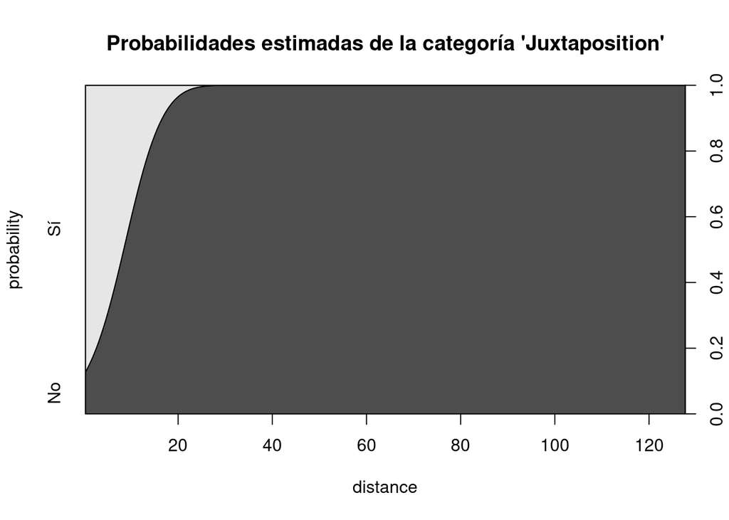

```r
cdplot(probability ~ distance, data=logreg, subset=structure == "juxtaposition",
       main="Probabilidades estimadas de la categoría 'Juxtaposition'")
```

Veamos el caso de las otras categorías:

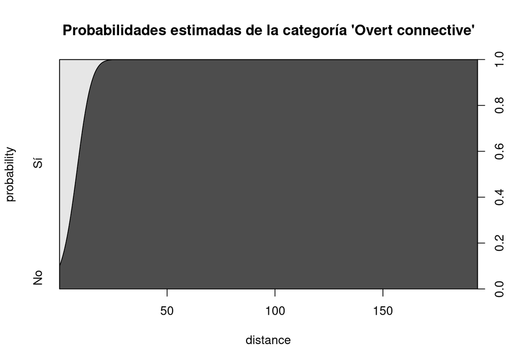

```r
cdplot(probability ~ distance, data=logreg, subset=structure == "overt connective",
       main="Probabilidades estimadas de la categoría 'Overt connective'")
```

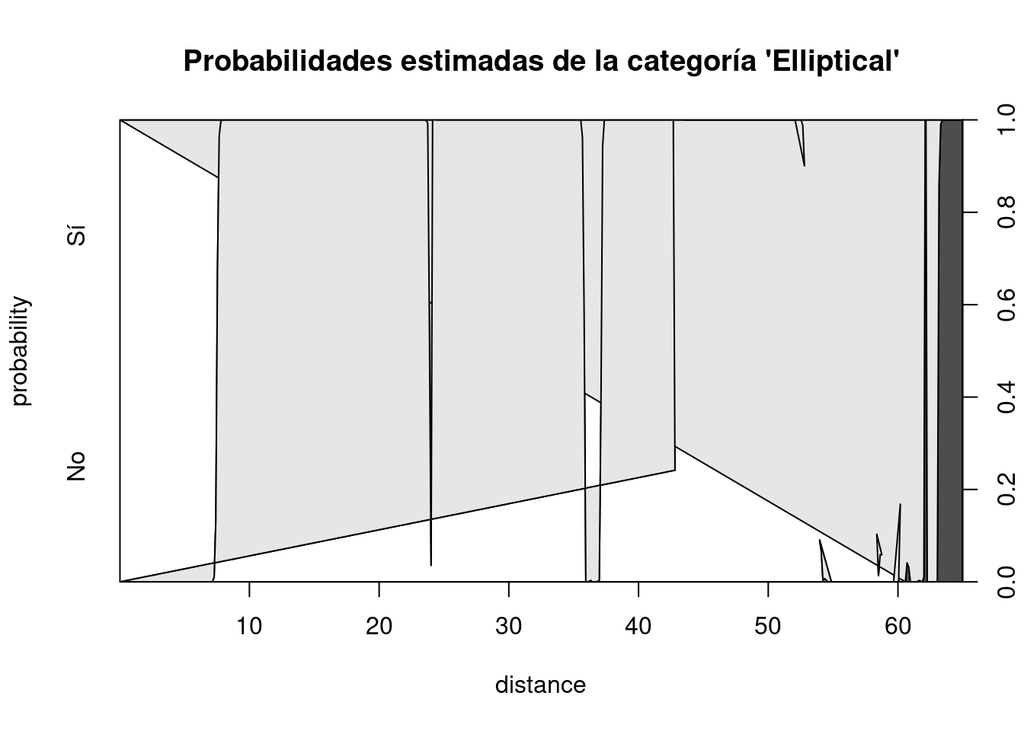

```r
cdplot(probability ~ distance, data=logreg, subset=structure == "elliptical",
       main="Probabilidades estimadas de la categoría 'Elliptical'")
```

Como podemos notar, el análisis funciona bien, a excepción de la categoría **elliptical** que -por su propia naturaleza- es difícil de predecir. De hecho, esto lo podemos notar si comparamos los histogramas de densidad de cada categoría:

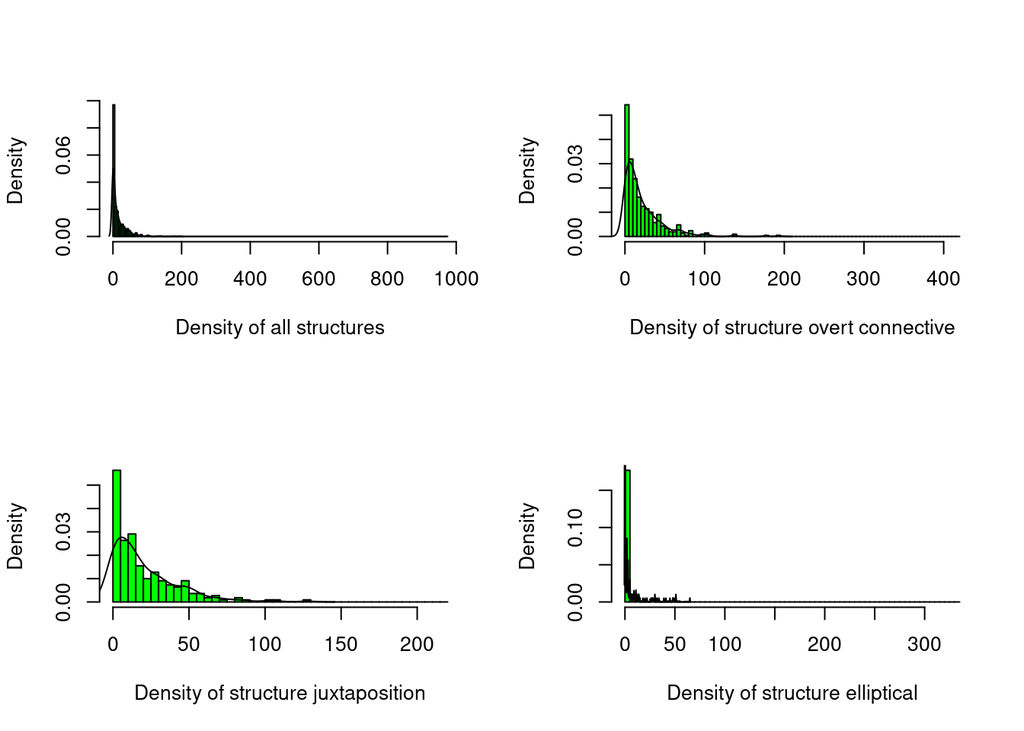

```r
density_histogram <- function(type) {
  if(missing(type)) {
    input <- df$distance
    text <- paste("Density of all structures")
  } else {
    input <- df$distance[df$structure==type]
    text <- paste("Density of structure", type)
  }
  hist(input,
       freq = FALSE,
       col = "green",
       breaks = seq(0, length(input), by = 5),
       #xlim = c(0, length(input)/5),
       xlab = text,
       main=NULL)
  lines(density(input))
}

par(mfrow=c(2,2))
density_histogram()
density_histogram("overt connective")
density_histogram("juxtaposition")
density_histogram("elliptical")
```

En el caso de la categoría **elliptical**, su densidad está demasiada concentrada alrededor de la distancia 0. Por esta razón, no parece ser posible que el análisis logístico funcione en su caso. Debido a esto, el modelo no converge, como usualmente hace.

```r
(glmFit <- glm(probability ~ distance + structure, family=binomial(link="logit"),
               data=logreg))
```

```
##
## Call:  glm(formula = probability ~ distance + structure, family = binomial(link = "logit"),
##     data = logreg)
##
## Coefficients:
##               (Intercept)                   distance
##                 -267.1602                    35.6415
##    structurejuxtaposition  structureovert connective
##                   -0.3763                    -0.3409
##
## Degrees of Freedom: 976 Total (i.e. Null);  973 Residual
## Null Deviance:       1352
## Residual Deviance: 1.694e-06     AIC: 8
```

A estas alturas, la solución más simple sería eliminar la categoría **elliptical** e intentarlo únicamente con las otras dos. Sin embargo, se me ocurrió que podríamos aplicar un modelo *naive bayes* común en *machine learning*.